# Anomaly_Detection

Nathan_Njonge

7/17/2021

## PROBLEM DEFINITION

You are a Data analyst at Carrefour Kenya and are currently undertaking a project that will inform the marketing department on the most relevant marketing strategies that will result in the highest no. of sales (total price including tax). Your project has been divided into four parts where you’ll explore a recent marketing dataset by performing various unsupervised learning techniques and later providing recommendations based on your insights.

```r
# load our dataset
df <- read.csv("http://bit.ly/CarreFourSalesDataset", header=TRUE)
```

```r
# preview the top of our dataset
head(df)
```

```
##        Date    Sales
## 1  1/5/2019 548.9715
## 2  3/8/2019  80.2200
## 3  3/3/2019 340.5255
## 4 1/27/2019 489.0480
## 5  2/8/2019 634.3785
## 6 3/25/2019 627.6165
```

```r
# preview the bottom of our dataset
tail(df)
```

```
##           Date     Sales
## 995  2/18/2019   63.9975
## 996  1/29/2019   42.3675
## 997   3/2/2019 1022.4900
## 998   2/9/2019   33.4320
## 999  2/22/2019   69.1110
## 1000 2/18/2019  649.2990
```

```r
# view the dimensions of our dataset
dim(df)
```

```
## [1] 1000    2
```

> Our dataset has 1000 rows and 2 columns

```r
# structure of our dataset
str(df)
```

```
## 'data.frame':    1000 obs. of  2 variables:
##  $ Date : chr  "1/5/2019" "3/8/2019" "3/3/2019" "1/27/2019" ...
##  $ Sales: num  549 80.2 340.5 489 634.4 ...
```

```r
# convert Date data type
df$Date <- as.Date(df$Date , "%m/%d/%Y" )
```

```r
# view the total missing values in the columns
colSums(is.na(df))
```

```
##  Date Sales
##     0     0
```

> There are no missing values in our dataset.

```r
# find any duplicated rows in our dataset
duplicated_rows <- df[duplicated(df),]
duplicated_rows
```

```
## [1] Date  Sales
## <0 rows> (or 0-length row.names)
```

> There are no duplicated rows in our dataset.

# Handling Outliers

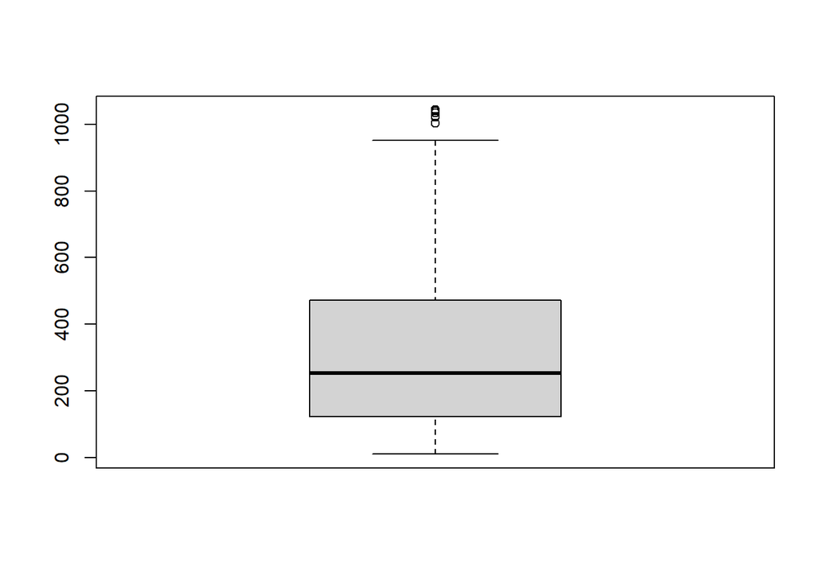

```r
# checking for outliers on the Sales column
boxplot(df$Sales)
```

```r
boxplot.stats(df$Sales)$out
```

```
## [1] 1003.590 1039.290 1042.650 1002.120 1020.705 1034.460 1023.750 1022.385
## [9] 1022.490
```

> The outliers in the sales column are as a result of the high amount of sales.

# Exploratory Data Analysis

## Univariate Analysis

### 1.Measures of Central Tendency & Measures of Dispersion

```r
summary(df)
```

```
##       Date                Sales
##  Min.   :2019-01-01   Min.   :  10.68
##  1st Qu.:2019-01-24   1st Qu.: 124.42
##  Median :2019-02-13   Median : 253.85
##  Mean   :2019-02-14   Mean   : 322.97
##  3rd Qu.:2019-03-08   3rd Qu.: 471.35
##  Max.   :2019-03-30   Max.   :1042.65
```

```r
# confirm the data type
str(df)
```

```
## 'data.frame':    1000 obs. of  2 variables:
##  $ Date : Date, format: "2019-01-05" "2019-03-08" ...
##  $ Sales: num  549 80.2 340.5 489 634.4 ...
```

```r
# mode function
getmode <- function(v) {
   uniqv <- unique(v)
   uniqv[which.max(tabulate(match(v, uniqv)))]
}
```

```r
#  mode of numerical columns
library(dplyr)
df %>% summarize_if(is.numeric, getmode)
```

```
##    Sales
## 1 829.08
```

> The mode of sales is 829.08

```r
# range of Sales column
df %>% summarize_if(is.numeric, range)
```

```
##       Sales
## 1   10.6785
## 2 1042.6500
```

> The range of the Sales column is from 10.68 to 1042.65

```r
# Quantile of Sales column
df %>% summarize_if(is.numeric, quantile)
```

```
##       Sales
## 1   10.6785
## 2  124.4224
## 3  253.8480
## 4  471.3502
## 5 1042.6500
```

```r
# Variance of Sales column
df %>% summarize_if(is.numeric, var)
```

```
##     Sales
## 1 60459.6
```

> The variance of our sales column is 60,459.6

```r
# Standard Deviation of Sales column
df %>% summarize_if(is.numeric, sd)
```

```
##      Sales
## 1 245.8853
```

> The standard deviation of Sales column is 245.89

### Univariate Graphical

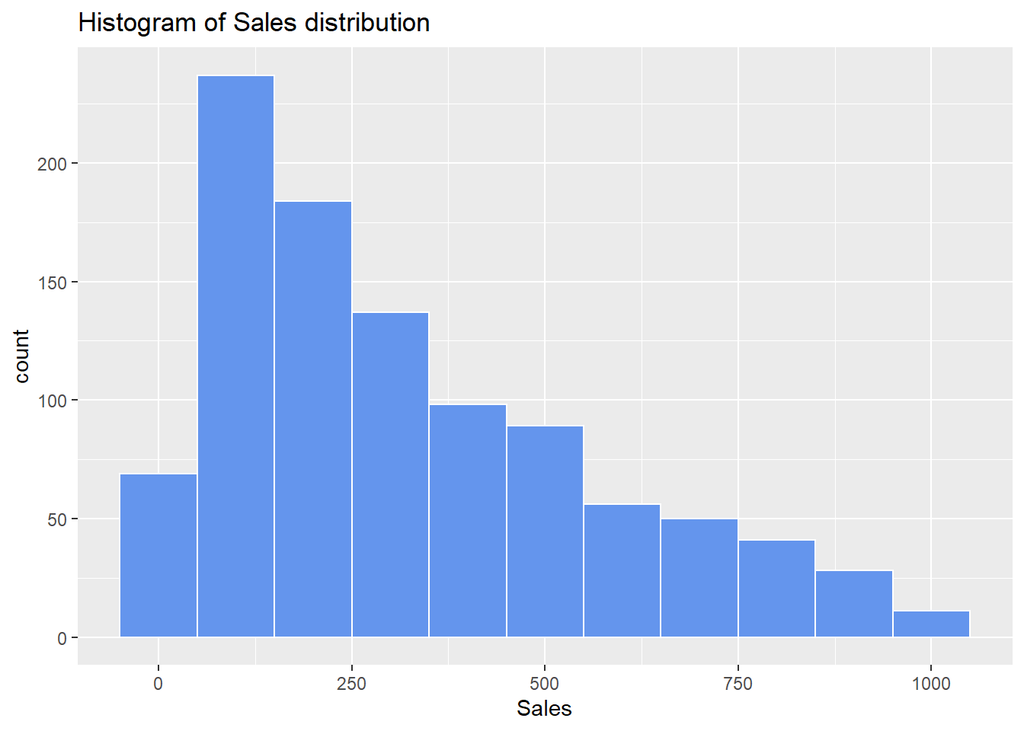

```r
# histogram of sales distribution
library(ggplot2)
ggplot(df, aes(x = Sales)) +
  geom_histogram(fill = "cornflowerblue",
                 color = "white",
                 binwidth = 100) +
  labs(title="Histogram of Sales distribution",
       x = "Sales")
```

> histogram of sales frequency.

## Solution implementation

```r
# devtools::install_github("business-science/tibbletime")
library(tibbletime)
df.tibble <- as_tibble(df)
```

```r
library(tidyverse)
library(anomalize)
library(future)
library(fracdiff)
library(lmtest)
library(tseries)
```

```
## Converting from tbl_df to tbl_time.
## Auto-index message: index = Date
```

```
## frequency = 7 days
```

```
## trend = 30 days
```

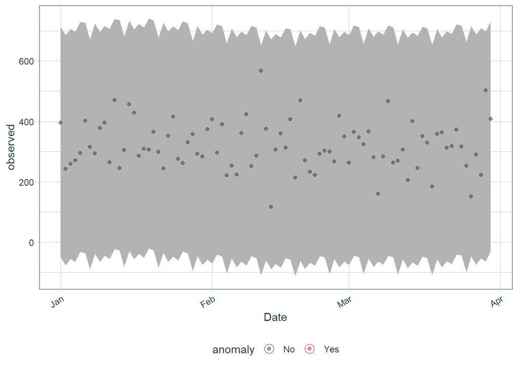

```r
library(Rcpp)

df %>%
  as_tibble() %>%
  group_by(Date) %>%
  summarise(Sales = mean(Sales)) %>%
  time_decompose(Sales,method = "stl") %>%
  anomalize(remainder) %>%
  time_recompose() %>%
  plot_anomalies(time_recomposed = TRUE, ncol = 3, alpha_dots = 0.5)
```

> There appears to be no anomalies in our dataset.